# Supplement 3

Binomial test analysis: Does the distribution of ratings differ from a theoretical ‘NULL’ distribution?

Peter Kamerman and Tory Madden

13 Nov 2018

# Question

For each participant, and at each stimulus intensity, does the distribution of SPARS, NRS, or SRS ratings differ significantly from a theoretical ‘NULL’ distribution?

To answer the question, we used the binomial test. The binomial test is an exact test of the statistical significance of deviations from a theoretically expected distribution of observations into two categories. As such, using the test required that we dichotomize the continuous rating data we collected (generally not a good thing, but here it is appropriate).

The SRS ranges from -100 (‘no sensation’) to 0 (‘just painful/pain threshold’), and therefore ratings immediately to the left of the 0-point of the scale mark the transition from non-painful to painful sensation. We therefore coded SRS ratings = 0 as being **‘positive’**, and ratings < 0 as being **‘negative’**.

In all cases, we modelled the data using the binomial test with a 50% probability of ‘success’ (positive rating arbitrarily chosen as success). This is a conservative approach as one would expect that for the SPARS and the NRS, as stimulus intensity increases above pain threshold, the probability of recording a ‘positive’ rating increases. Similarly, in the case of the SPARS (which allows the rating of intensity of noxious and non-noxious stimuli), one would expect that the probability of recording a ‘negative’ rating would increase as stimulus intensity decreased. However, since we did not know the approximate intensity of a theshold stimulus, and there was high inter-individual variation in sensitivity, we were unable to gage at which stimulus intensities we should start shifting the probability of ‘success’ away from 50% (see Supplement 1 and Supplement 2).

Because ratings on the SPARS can range from -50 to +50, we analysed the data using a two-tailed p-value. That is, the distribution may shift to the left or right of the theoretical distribution. However, because the NRS has a floor rating of 0 (‘no pain’) and the SRS has a ceiling rating of 0 (‘pain threshold’), the change in rating from 0 is unidirectional (> 0), so we performed the binomial test with a one-tailed p-value. For all test, significance was assessed at the $\alpha$ = 0.05 level. And, because this was an exploratory analysis, we did not make any family-wide corrections for multiple comparisons.

# SPARS A

## Import and inspect data

```r
# Import
data_sparsA <- read_rds('data-cleaned/SPARS_A.rds')

# Inspect
glimpse(data_sparsA)
```

```
## Observations: 1,927
## Variables: 6
## $ PID          <chr> "ID01", "ID01", "ID01", "ID01", "ID01", "ID01", "...
## $ block        <chr> "A", "A", "A", "A", "A", "A", "A", "A", "A", "A",...
## $ block_order  <dbl> 4, 4, 4, 4, 4, 4, 4, 4, 4, 4, 4, 4, 4, 4, 4, 4, 4...
## $ trial_number <dbl> 79, 80, 81, 82, 83, 84, 85, 86, 87, 88, 89, 90, 9...
## $ intensity    <dbl> 3.00, 2.25, 4.00, 3.25, 2.75, 2.25, 2.75, 4.00, 2...
## $ rating       <dbl> -40, -25, 10, 2, -10, -25, -20, 10, -25, -50, -25...
```

```r
data_sparsA %>%
    select(intensity, rating) %>%
    skim()
```

```
## Skim summary statistics
##  n obs: 1927
##  n variables: 2
##
## ── Variable type:numeric ───────────────────────────────────────────────────────────────
##   variable missing complete    n  mean    sd  p0    p25 p50   p75 p100
##  intensity       0     1927 1927  2.47  0.93   1   1.75 2.5  3.25    4
##     rating       0     1927 1927 -4.45 22.31 -50 -20    2   10      45
##      hist
##  ▇▇▃▇▃▇▃▇
##  ▃▁▂▃▇▅▂▁
```

## Binomial test

```r
# Select columns
data_sparsA %<>%
    select(PID, intensity, rating)

# Nest data by PID and stimulus intensity
sparsA_nest <- data_sparsA %>%
    group_by(PID, intensity) %>%
    nest()

# Generate data
sparsA_nest %<>%
    # Add probability of success column
    mutate(prob = 0.5) %>%
    # Extract rating data from dataframe
    mutate(data_vec = map(.x = data,
                          ~ .$rating)) %>%
    # Recode rating data as categories according to sign
    mutate(data_cat = map(.x = data_vec,
                          ~ ifelse(.x < 0,
                                   yes = 'negative',
                                   no = 'positive'))) %>%
    # Count the number of positive and negative ratings
    ## positive numbers arbitrarily listed first == 'success'
    mutate(success_count = map(.x = data_cat,
                           ~ c(length(.x[.x == 'positive']),
                               length(.x[.x == 'negative'])))) %>%
    # Conduct binomial test (two-sided)
    mutate(binomial_test = map2(.x = success_count,
                                .y = prob,
                                ~ binom.test(x = .x,
                                             p = .y,
                                             alternative = 'two.sided'))) %>%
    # Extract p-value from binomial_test
    mutate(binomial_p.value = map(.x = binomial_test,
                                 ~ .x$p.value %>%
                                     round(., 3))) %>%
    # Categorise p-value using a p < 0.05 threshold
    ## Significant: distribution deviates significantly
    ## from the theoretical distribution
    ## No correction for multiple comparisons
    ## (too conservative for explorartory analysis)
    mutate(significant_p.value = map(.x = binomial_p.value,
                                     ~ ifelse(.x < 0.05,
                                              yes = 'yes',
                                              no = 'no')))
```

## Plot

For each paticipant, we plotted raw SPARS ratings at each stimulus intensity and colour-coded the data according to whether the p-value returned by the binomial test was significant (distribution of data points deviates significantly from the theoretical expected distribution).

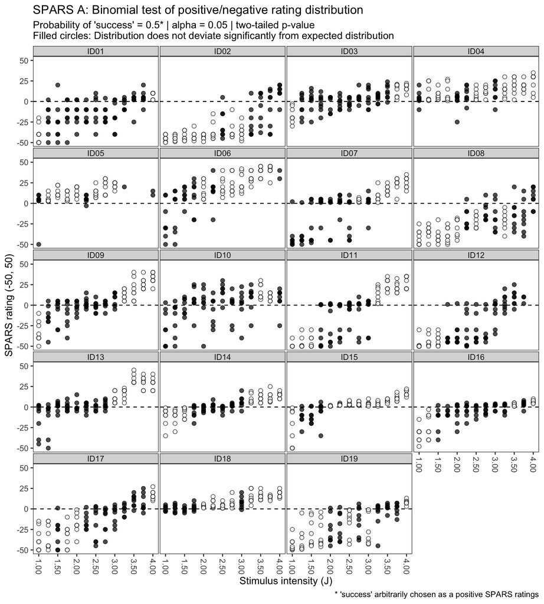

```r
sparsA_nest %>%
    # Select data columns
    select(PID, intensity, significant_p.value) %>%
    # Unnest data
    unnest() %>%
    # Join with original data
    right_join(data_sparsA) %>%
    # Reclass intensity as an ordered factor
    mutate(intensity = factor(intensity,
                              ordered = TRUE)) %>%
    # Plot
    ggplot(data = .) +
    aes(x = intensity,
        y = rating,
        fill = significant_p.value) +
    geom_hline(yintercept = 0,
               linetype = 2) +
    geom_point(colour = '#000000',
               shape = 21,
               size = 2,
               alpha = 0.7) +
    labs(title = "SPARS A: Binomial test of positive/negative rating distribution",
         subtitle = "Probability of 'success' = 0.5* | alpha = 0.05 | two-tailed p-value\nFilled circles: Distribution does not deviate significantly from expected distribution",
         caption = "* 'success' arbitrarily chosen as a positive SPARS ratings",
         x = 'Stimulus intensity (J)',
         y = 'SPARS rating (-50, 50)') +
    scale_x_discrete(breaks = seq(from = 1,
                                  to = 4,
                                  by = 0.5),
                     labels = sprintf('%.2f', seq(from = 1,
                                                  to = 4,
                                                  by = 0.5))) +
    scale_y_continuous(limits = c(-50, 50),
                       breaks = c(-50, -25, 0, 25, 50),
                       labels = c(-50, -25, 0, 25, 50)) +
    scale_fill_manual(values = c('#000000', '#FFFFFF')) +
    facet_wrap(~ PID, ncol = 4) +
    theme(legend.position = 'none',
          panel.grid = element_blank(),
          panel.spacing = unit(0.1, 'lines'),
          strip.text = element_text(margin = margin(t = 0.1,
                                                    b = 0.1,
                                                    r = 1,
                                                    l = 1,
                                                    'lines')),
          axis.text.x = element_text(angle = -90,
                                     vjust = 0.5))
```

# SPARS B

## Import and inspect data

```r
# Import
data_sparsB <- read_rds('data-cleaned/SPARS_B.rds') %>%
    # Extract trials rated using the SPARS
    filter(scale == 'SPARS') %>%
    # Remove <NA>
    filter(!is.na(rating))

# Rank stimulus intensity
data_sparsB %<>%
    group_by(PID, scale) %>%
    arrange(intensity) %>%
    mutate(intensity_rank = dense_rank(intensity)) %>%
    select(-intensity) %>%
    rename(intensity = intensity_rank) %>%
    ungroup()

# Inspect
glimpse(data_sparsB)
```

```
## Observations: 752
## Variables: 6
## $ PID          <chr> "ID06", "ID06", "ID06", "ID06", "ID06", "ID06", "...
## $ block_number <int> 1, 1, 1, 2, 2, 2, 3, 3, 3, 4, 4, 4, 1, 1, 1, 2, 2...
## $ trial_number <int> 4, 6, 27, 9, 13, 20, 20, 24, 27, 4, 18, 22, 5, 16...
## $ scale        <chr> "SPARS", "SPARS", "SPARS", "SPARS", "SPARS", "SPA...
## $ rating       <dbl> -49, 2, -6, 3, -20, -2, -31, 2, -5, -8, -23, 14, ...
## $ intensity    <int> 1, 1, 1, 1, 1, 1, 1, 1, 1, 1, 1, 1, 2, 2, 2, 2, 2...
```

```r
data_sparsB %>%
    select(intensity, rating) %>%
    skim()
```

```
## Skim summary statistics
##  n obs: 752
##  n variables: 2
##
## ── Variable type:integer ───────────────────────────────────────────────────────────────
##   variable missing complete   n mean   sd p0 p25 p50 p75 p100     hist
##  intensity       0      752 752    5 2.58  1   3   5   7    9 ▇▅▅▅▃▅▅▃
##
## ── Variable type:numeric ───────────────────────────────────────────────────────────────
##  variable missing complete   n  mean    sd  p0 p25 p50 p75 p100     hist
##    rating       0      752 752 -8.83 23.46 -50 -26  -4   5   50 ▆▂▃▇▇▃▁▁
```

```r
# Number of 0 ratings
data_sparsB %>%
    # Retain ratings of 0
    filter(rating == 0) %>%
    # Select columns
    select(PID, intensity, rating) %>%
    # Group by individual and intensity
    group_by(PID, intensity) %>%
    # Summarise
    summarise(zero_count = n()) %>%
    ftable(.)
```

```
##                zero_count 1 2 3 4
## PID  intensity
## ID01 1                    0 0 0 0
##      2                    0 0 0 0
##      3                    0 0 0 0
##      5                    0 0 0 1
##      6                    1 0 0 0
##      7                    0 0 1 0
##      8                    0 0 0 0
##      9                    0 0 0 0
## ID02 1                    1 0 0 0
##      2                    0 0 0 0
##      3                    0 0 0 0
##      5                    0 0 0 0
##      6                    1 0 0 0
```

[output cut: 35 more lines]

## Binomial test

```r
# Select data
data_sparsB %<>%
    # Remove ratings of 0
    filter(rating != 0) %>%
    # Select columns
    select(PID, intensity, rating)

# Nest data by PID and stimulus intensity
sparsB_nest <- data_sparsB %>%
    group_by(PID, intensity) %>%
    nest()

# Generate data
sparsB_nest %<>%
    # Add probability of success column
    mutate(prob = 0.5) %>%
    # Extract rating data from dataframe
    mutate(data_vec = map(.x = data,
                          ~ .$rating)) %>%
    # Recode rating data as categories according to sign
    mutate(data_cat = map(.x = data_vec,
                          ~ ifelse(.x < 0,
                                   yes = 'negative',
                                   no = 'positive'))) %>%
    # Count the number of positive and negative ratings
    ## positive numbers arbitrarily listed first == 'success'
    mutate(success_count = map(.x = data_cat,
                           ~ c(length(.x[.x == 'positive']),
                               length(.x[.x == 'negative'])))) %>%
    # Conduct binomial test (two-sided)
    mutate(binomial_test = map2(.x = success_count,
                                .y = prob,
                                ~ binom.test(x = .x,
                                             p = .y,
                                             alternative = 'two.sided'))) %>%
    # Extract p-value from binomial_test
    mutate(binomial_p.value = map(.x = binomial_test,
                                 ~ .x$p.value %>%
                                     round(., 3))) %>%
    # Categorise p-value using a p < 0.05 threshold
    ## Significant: distribution deviates significantly
    ## from the theoretical distribution
    ## No correction for multiple comparisons
    ## (too conservative for explorartory analysis)
    mutate(significant_p.value = map(.x = binomial_p.value,
                                     ~ ifelse(.x < 0.05,
                                              yes = 'yes',
                                              no = 'no')))
```

## Plot

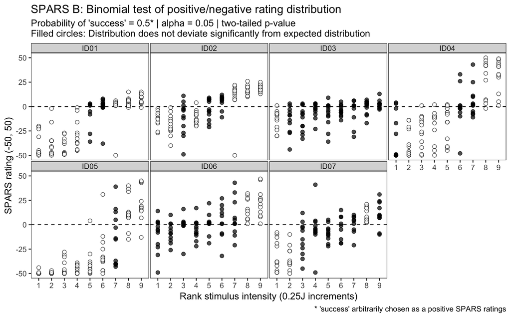

```r
sparsB_nest %>%
    # Select data columns
    select(PID, intensity, significant_p.value) %>%
    # Unnest data
    unnest() %>%
    # Join with original data
    right_join(data_sparsB) %>%
    # Reclass intensity as an ordered factor
    mutate(intensity = factor(intensity,
                              ordered = TRUE)) %>%
    # Plot
    ggplot(data = .) +
    aes(x = intensity,
        y = rating,
        fill = significant_p.value) +
    geom_hline(yintercept = 0,
               linetype = 2) +
    geom_point(colour = '#000000',
               shape = 21,
               size = 2,
               alpha = 0.7) +
    labs(title = "SPARS B: Binomial test of positive/negative rating distribution",
         subtitle = "Probability of 'success' = 0.5* | alpha = 0.05 | two-tailed p-value\nFilled circles: Distribution does not deviate significantly from expected distribution",
         caption = "* 'success' arbitrarily chosen as a positive SPARS ratings",
         x = 'Rank stimulus intensity (0.25J increments)',
         y = 'SPARS rating (-50, 50)') +
    scale_x_discrete(breaks = seq(from = 1,
                                  to = 9,
                                  by = 1),
                     labels = sprintf('%.0f', seq(from = 1,
                                                  to = 9,
                                                  by = 1))) +
    scale_y_continuous(limits = c(-50, 50),
                       breaks = c(-50, -25, 0, 25, 50),
                       labels = c(-50, -25, 0, 25, 50)) +
    scale_fill_manual(values = c('#000000', '#FFFFFF')) +
    facet_wrap(~ PID, ncol = 4) +
    theme(legend.position = 'none',
          panel.grid = element_blank(),
          panel.spacing = unit(0.1, 'lines'),
          strip.text = element_text(margin = margin(t = 0.1,
                                                    b = 0.1,
                                                    r = 1,
                                                    l = 1,
                                                    'lines')))
```

# NRS (zero: 0)

## Import and inspect data

```r
# Import
data_nrs <- read_rds('data-cleaned/SPARS_B.rds') %>%
    # Extract trials rated using the SPARS
    filter(scale == 'NRS') %>%
    # Remove <NA>
    filter(!is.na(rating))

# Rank stimulus intensity
data_nrs %<>%
    group_by(PID, scale) %>%
    arrange(intensity) %>%
    mutate(intensity_rank = dense_rank(intensity)) %>%
    select(-intensity) %>%
    rename(intensity = intensity_rank) %>%
    ungroup()

# Inspect
glimpse(data_nrs)
```

```
## Observations: 753
## Variables: 6
## $ PID          <chr> "ID06", "ID06", "ID06", "ID06", "ID06", "ID06", "...
## $ block_number <int> 9, 9, 9, 10, 10, 10, 11, 11, 11, 12, 12, 12, 9, 9...
## $ trial_number <int> 7, 9, 26, 4, 9, 27, 2, 4, 12, 4, 7, 10, 5, 6, 27,...
## $ scale        <chr> "NRS", "NRS", "NRS", "NRS", "NRS", "NRS", "NRS", ...
## $ rating       <dbl> 5, 2, 0, 0, 0, 0, 0, 1, 0, 0, 0, 48, 1, 0, 53, 0,...
## $ intensity    <int> 1, 1, 1, 1, 1, 1, 1, 1, 1, 1, 1, 1, 2, 2, 2, 2, 2...
```

```r
data_nrs %>%
    select(intensity, rating) %>%
    skim()
```

```
## Skim summary statistics
##  n obs: 753
##  n variables: 2
##
## ── Variable type:integer ───────────────────────────────────────────────────────────────
##   variable missing complete   n mean   sd p0 p25 p50 p75 p100     hist
##  intensity       0      753 753    5 2.59  1   3   5   7    9 ▇▅▅▃▃▅▅▅
##
## ── Variable type:numeric ───────────────────────────────────────────────────────────────
##  variable missing complete   n  mean    sd p0 p25 p50 p75 p100     hist
##    rating       0      753 753 19.63 26.82  0   1   5  28   98 ▇▂▁▁▁▁▁▁
```

```r
# Number of 0 ratings
data_nrs %>%
    # Retain ratings of 0
    filter(rating == 0) %>%
    # Select columns
    select(PID, intensity, rating) %>%
    # Group by individual and intensity
    group_by(PID, intensity) %>%
    # Summarise
    summarise(zero_count = n()) %>%
    ftable(.)
```

```
##                zero_count 1 2 3 4 5 6 7 8 10 12
## PID  intensity
## ID01 1                    0 0 0 0 0 0 0 0  0  1
##      2                    0 0 0 0 0 0 0 0  1  0
##      3                    0 0 0 0 0 0 0 0  1  0
##      4                    0 0 0 1 0 0 0 0  0  0
##      5                    0 0 0 1 0 0 0 0  0  0
##      6                    0 0 0 0 0 0 0 0  0  0
##      7                    0 1 0 0 0 0 0 0  0  0
## ID02 1                    0 0 0 0 0 0 0 0  1  0
##      2                    0 0 0 0 0 0 1 0  0  0
##      3                    0 0 1 0 0 0 0 0  0  0
##      4                    0 0 0 0 0 0 0 0  0  0
##      5                    0 0 0 0 0 0 0 0  0  0
##      6                    0 0 0 0 0 0 0 0  0  0
```

[output cut: 29 more lines]

## Binomial test

```r
# Select data
data_nrs %<>%
    # Select columns
    select(PID, intensity, rating)

# Nest data by PID and stimulus intensity
nrs_nest <- data_nrs %>%
    group_by(PID, intensity) %>%
    nest()

# Generate data
nrs0_nest <- nrs_nest %>%
    # Add probability of success column
    mutate(prob = 0.5) %>%
    # Extract rating data from dataframe
    mutate(data_vec = map(.x = data,
                          ~ .$rating)) %>%
    # Recode rating data as categories according to whether
    # the value is greater than 0 (minimum rating on NRS)
    mutate(data_cat = map(.x = data_vec,
                          ~ ifelse(.x == 0,
                                   yes = 'negative',
                                   no = 'positive'))) %>%
    # Count the number of positive and negative ratings
    ## positive numbers arbitrarily listed first == 'success'
    mutate(success_count = map(.x = data_cat,
                           ~ c(length(.x[.x == 'positive']),
                               length(.x[.x == 'negative'])))) %>%
    # Conduct binomial test (two-sided)
    mutate(binomial_test = map2(.x = success_count,
                                .y = prob,
                                ~ binom.test(x = .x,
                                             p = .y,
                                             alternative = 'greater'))) %>%
    # Extract p-value from binomial_test
    mutate(binomial_p.value = map(.x = binomial_test,
                                 ~ .x$p.value %>%
                                     round(., 3))) %>%
    # Categorise p-value using a p < 0.05 threshold
    ## Significant: distribution deviates significantly
    ## from the theoretical distribution
    ## No correction for multiple comparisons
    ## (too conservative for explorartory analysis)
    mutate(significant_p.value = map(.x = binomial_p.value,
                                     ~ ifelse(.x < 0.05,
                                              yes = 'yes',
                                              no = 'no')))
```

## Plot

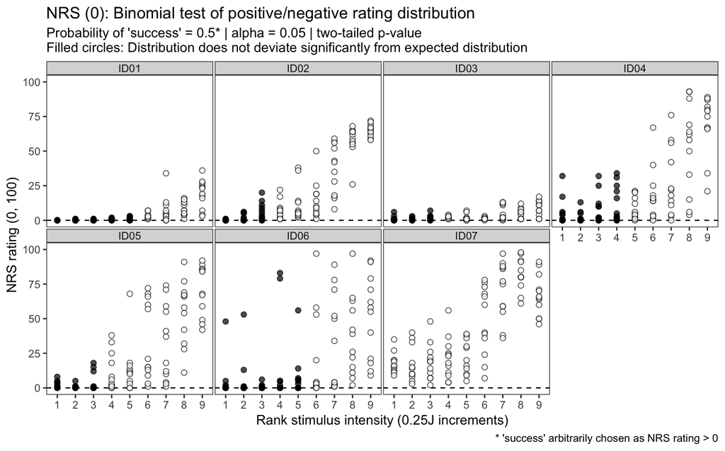

```r
nrs0_nest %>%
    # Select data columns
    select(PID, intensity, significant_p.value) %>%
    # Unnest data
    unnest() %>%
    # Join with original data
    right_join(data_nrs) %>%
    # Reclass intensity as an ordered factor
    mutate(intensity = factor(intensity,
                              ordered = TRUE)) %>%
    # Plot
    ggplot(data = .) +
    aes(x = intensity,
        y = rating,
        fill = significant_p.value) +
    geom_hline(yintercept = 0,
               linetype = 2) +
    geom_point(colour = '#000000',
               shape = 21,
               size = 2,
               alpha = 0.7) +
    labs(title = "NRS (0): Binomial test of positive/negative rating distribution",
         subtitle = "Probability of 'success' = 0.5* | alpha = 0.05 | two-tailed p-value\nFilled circles: Distribution does not deviate significantly from expected distribution",
         caption = "* 'success' arbitrarily chosen as NRS rating > 0",
         x = 'Rank stimulus intensity (0.25J increments)',
         y = 'NRS rating (0, 100)') +
    scale_x_discrete(breaks = seq(from = 1,
                                  to = 9,
                                  by = 1),
                     labels = sprintf('%.0f', seq(from = 1,
                                                  to = 9,
                                                  by = 1))) +
    scale_y_continuous(limits = c(0, 100),
                       breaks = c(0, 25, 50, 75, 100),
                       labels = c(0, 25, 50, 75, 100)) +
    scale_fill_manual(values = c('#000000', '#FFFFFF')) +
    facet_wrap(~ PID, ncol = 4) +
    theme(legend.position = 'none',
          panel.grid = element_blank(),
          panel.spacing = unit(0.1, 'lines'),
          strip.text = element_text(margin = margin(t = 0.1,
                                                    b = 0.1,
                                                    r = 1,
                                                    l = 1,
                                                    'lines')))
```

# NRS (zero: 0 to 15)

## Import and inspect data

Data already imported, inspected, and nested *(data_nrs, nrs_nest)*.

## Binomial test

```r
# Generate data
nrs15_nest <- nrs_nest %>%
    # Add probability of success column
    mutate(prob = 0.5) %>%
    # Extract rating data from dataframe
    mutate(data_vec = map(.x = data,
                          ~ .$rating)) %>%
    # Recode rating data as categories according to whether
    # the value is greater than 0 (minimum rating on NRS)
    mutate(data_cat = map(.x = data_vec,
                          ~ ifelse(.x <= 15,
                                   yes = 'negative',
                                   no = 'positive'))) %>%
    # Count the number of positive and negative ratings
    ## positive numbers arbitrarily listed first == 'success'
    mutate(success_count = map(.x = data_cat,
                           ~ c(length(.x[.x == 'positive']),
                               length(.x[.x == 'negative'])))) %>%
    # Conduct binomial test (two-sided)
    mutate(binomial_test = map2(.x = success_count,
                                .y = prob,
                                ~ binom.test(x = .x,
                                             p = .y,
                                             alternative = 'greater'))) %>%
    # Extract p-value from binomial_test
    mutate(binomial_p.value = map(.x = binomial_test,
                                 ~ .x$p.value %>%
                                     round(., 3))) %>%
    # Categorise p-value using a p < 0.05 threshold
    ## Significant: distribution deviates significantly
    ## from the theoretical distribution
    ## No correction for multiple comparisons
    ## (too conservative for explorartory analysis)
    mutate(significant_p.value = map(.x = binomial_p.value,
                                     ~ ifelse(.x < 0.05,
                                              yes = 'yes',
                                              no = 'no')))
```

## Plot

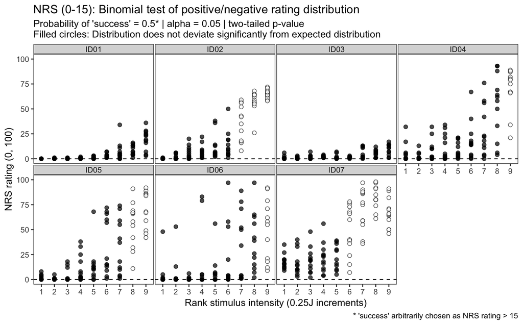

```r
nrs15_nest %>%
    # Select data columns
    select(PID, intensity, significant_p.value) %>%
    # Unnest data
    unnest() %>%
    # Join with original data
    right_join(data_nrs) %>%
    # Reclass intensity as an ordered factor
    mutate(intensity = factor(intensity,
                              ordered = TRUE)) %>%
    # Plot
    ggplot(data = .) +
    aes(x = intensity,
        y = rating,
        fill = significant_p.value) +
    geom_hline(yintercept = 0,
               linetype = 2) +
    geom_point(colour = '#000000',
               shape = 21,
               size = 2,
               alpha = 0.7) +
    labs(title = "NRS (0-15): Binomial test of positive/negative rating distribution",
         subtitle = "Probability of 'success' = 0.5* | alpha = 0.05 | two-tailed p-value\nFilled circles: Distribution does not deviate significantly from expected distribution",
         caption = "* 'success' arbitrarily chosen as NRS rating > 15",
         x = 'Rank stimulus intensity (0.25J increments)',
         y = 'NRS rating (0, 100)') +
    scale_x_discrete(breaks = seq(from = 1,
                                  to = 9,
                                  by = 1),
                     labels = sprintf('%.0f', seq(from = 1,
                                                  to = 9,
                                                  by = 1))) +
    scale_y_continuous(limits = c(0, 100),
                       breaks = c(0, 25, 50, 75, 100),
                       labels = c(0, 25, 50, 75, 100)) +
    scale_fill_manual(values = c('#000000', '#FFFFFF')) +
    facet_wrap(~ PID, ncol = 4) +
    theme(legend.position = 'none',
          panel.grid = element_blank(),
          panel.spacing = unit(0.1, 'lines'),
          strip.text = element_text(margin = margin(t = 0.1,
                                                    b = 0.1,
                                                    r = 1,
                                                    l = 1,
                                                    'lines')))
```

# SRS

## Import and inspect data

```r
# Import
data_srs <- read_rds('data-cleaned/SPARS_B.rds') %>%
    # Extract trials rated using the SRS
    filter(scale == 'SRS') %>%
    # Remove <NA>
    filter(!is.na(rating))

# Rank stimulus intensity
data_srs %<>%
    group_by(PID, scale) %>%
    arrange(intensity) %>%
    mutate(intensity_rank = dense_rank(intensity)) %>%
    select(-intensity) %>%
    rename(intensity = intensity_rank) %>%
    ungroup()

# Inspect
glimpse(data_srs)
```

```
## Observations: 644
## Variables: 6
## $ PID          <chr> "ID06", "ID06", "ID06", "ID06", "ID06", "ID06", "...
## $ block_number <int> 5, 5, 5, 6, 6, 6, 7, 7, 7, 8, 8, 8, 5, 5, 5, 6, 6...
## $ trial_number <int> 2, 16, 26, 13, 19, 21, 1, 17, 27, 2, 4, 5, 6, 24,...
## $ scale        <chr> "SRS", "SRS", "SRS", "SRS", "SRS", "SRS", "SRS", ...
## $ rating       <dbl> -34, -99, -89, -99, -100, -99, -59, -96, -70, -92...
## $ intensity    <int> 1, 1, 1, 1, 1, 1, 1, 1, 1, 1, 1, 1, 2, 2, 2, 2, 2...
```

```r
data_srs %>%
    select(intensity, rating) %>%
    skim()
```

```
## Skim summary statistics
##  n obs: 644
##  n variables: 2
##
## ── Variable type:integer ───────────────────────────────────────────────────────────────
##   variable missing complete   n mean   sd p0 p25 p50 p75 p100     hist
##  intensity       0      644 644    5 2.58  1   3   5   7    9 ▇▃▅▅▅▅▃▃
##
## ── Variable type:numeric ───────────────────────────────────────────────────────────────
##  variable missing complete   n   mean    sd   p0 p25 p50 p75 p100     hist
##    rating       0      644 644 -54.46 35.19 -100 -88 -63 -21    0 ▇▃▃▂▂▂▃▆
```

```r
# Number of 0 ratings
data_srs %>%
    # Retain ratings of 0
    filter(rating == 0) %>%
    # Select columns
    select(PID, intensity, rating) %>%
    # Group by individual and intensity
    group_by(PID, intensity) %>%
    # Summarise
    summarise(zero_count = n()) %>%
    ftable(.)
```

```
##                zero_count 1 2 3 5 9 12
## PID  intensity
## ID02 5                    0 1 0 0 0  0
##      6                    0 0 0 1 0  0
##      7                    0 0 0 0 1  0
##      8                    0 0 0 0 0  1
##      9                    0 0 0 0 0  1
## ID04 5                    0 0 0 0 0  0
##      6                    0 0 0 0 0  0
##      7                    0 0 0 0 0  0
##      8                    1 0 0 0 0  0
##      9                    1 0 0 0 0  0
## ID05 5                    0 0 0 0 0  0
##      6                    0 0 0 0 0  0
##      7                    0 0 0 0 0  0
##      8                    0 0 0 0 0  0
##      9                    1 0 0 0 0  0
## ID06 5                    0 0 0 0 0  0
##      6                    0 0 0 0 0  0
##      7                    1 0 0 0 0  0
##      8                    1 0 0 0 0  0
##      9                    0 0 1 0 0  0
```

## Binomial test

```r
# Select data
data_srs %<>%
    # Select columns
    select(PID, intensity, rating)

# Nest data by PID and stimulus intensity
srs_nest <- data_srs %>%
    group_by(PID, intensity) %>%
    nest()

# Generate data
srs_nest <- srs_nest %>%
    # Add probability of success column
    mutate(prob = 0.5) %>%
    # Extract rating data from dataframe
    mutate(data_vec = map(.x = data,
                          ~ .$rating)) %>%
    # Recode rating data as categories according to whether
    # the value is less than 0 (maximum rating on srs)
    mutate(data_cat = map(.x = data_vec,
                          ~ ifelse(.x == 0,
                                   yes = 'positive',
                                   no = 'negative'))) %>%
    # Count the number of positive and negative ratings
    ## positive numbers arbitrarily listed first == 'success'
    mutate(success_count = map(.x = data_cat,
                           ~ c(length(.x[.x == 'positive']),
                               length(.x[.x == 'negative'])))) %>%
    # Conduct binomial test (two-sided)
    mutate(binomial_test = map2(.x = success_count,
                                .y = prob,
                                ~ binom.test(x = .x,
                                             p = .y,
                                             alternative = 'greater'))) %>%
    # Extract p-value from binomial_test
    mutate(binomial_p.value = map(.x = binomial_test,
                                 ~ .x$p.value %>%
                                     round(., 3))) %>%
    # Categorise p-value using a p < 0.05 threshold
    ## Significant: distribution deviates significantly
    ## from the theoretical distribution
    ## No correction for multiple comparisons
    ## (too conservative for explorartory analysis)
    mutate(significant_p.value = map(.x = binomial_p.value,
                                     ~ ifelse(.x < 0.05,
                                              yes = 'yes',
                                              no = 'no')))
```

## Plot

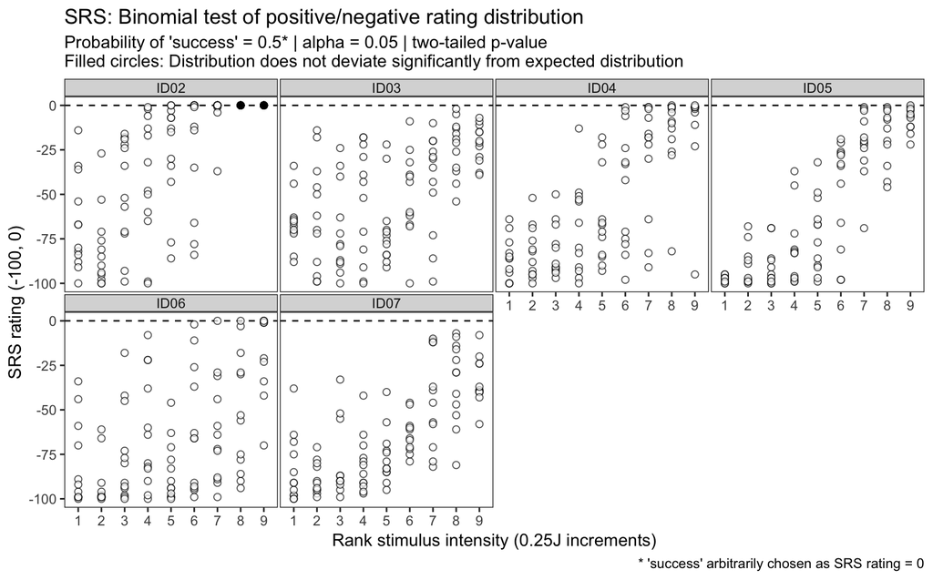

```r
srs_nest %>%
    # Select data columns
    select(PID, intensity, significant_p.value) %>%
    # Unnest data
    unnest() %>%
    # Join with original data
    right_join(data_srs) %>%
    # Reclass intensity as an ordered factor
    mutate(intensity = factor(intensity,
                              ordered = TRUE)) %>%
    # Plot
    ggplot(data = .) +
    aes(x = intensity,
        y = rating,
        fill = significant_p.value) +
    geom_hline(yintercept = 0,
               linetype = 2) +
    geom_point(colour = '#000000',
               shape = 21,
               size = 2,
               alpha = 0.7) +
    labs(title = "SRS: Binomial test of positive/negative rating distribution",
         subtitle = "Probability of 'success' = 0.5* | alpha = 0.05 | two-tailed p-value\nFilled circles: Distribution does not deviate significantly from expected distribution",
         caption = "* 'success' arbitrarily chosen as SRS rating = 0",
         x = 'Rank stimulus intensity (0.25J increments)',
         y = 'SRS rating (-100, 0)') +
    scale_x_discrete(breaks = seq(from = 1,
                                  to = 9,
                                  by = 1),
                     labels = sprintf('%.0f', seq(from = 1,
                                                  to = 9,
                                                  by = 1))) +
    scale_y_continuous(limits = c(-100, 0),
                       breaks = c(-100, -75, -50, -25, 0),
                       labels = c(-100, -75, -50, -25, 0)) +
    scale_fill_manual(values = c('#FFFFFF', '#000000')) +
    facet_wrap(~ PID, ncol = 4) +
    theme(legend.position = 'none',
          panel.grid = element_blank(),
          panel.spacing = unit(0.1, 'lines'),
          strip.text = element_text(margin = margin(t = 0.1,
                                                    b = 0.1,
                                                    r = 1,
                                                    l = 1,
                                                    'lines')))
```